# Splitting data into training and evaluation sets

Some Material taken from:

- *Python Machine Learning 2nd Edition by [Sebastian Raschka](https://sebastianraschka.com), Packt Publishing Ltd. 2017*
- *Code Repository: https://github.com/rasbt/python-machine-learning-book-2nd-edition*

```python
from IPython.display import Image
%matplotlib inline
```

## Loading the Breast Cancer Wisconsin dataset

Below, we'll use the Wisconsin breast cancer data set published in the 1990s:

- https://archive.ics.uci.edu/ml/datasets/Breast+Cancer+Wisconsin+(Diagnostic)
- https://archive.ics.uci.edu/ml/machine-learning-databases/breast-cancer-wisconsin/breast-cancer-wisconsin.names

It has the following attributes:

1. ID number
2. Diagnosis (M = malignant, B = benign)
3. -32.: Mean, standard deviation, and "worst" of the below for each cell nucleus:
   - radius (mean of distances from center to points on the perimeter)
   - texture (standard deviation of gray-scale values)
   - perimeter
   - area
   - smoothness (local variation in radius lengths)
   - compactness (perimeter^2 / area - 1.0)
   - concavity (severity of concave portions of the contour)
   - concave points (number of concave portions of the contour)
   - symmetry
   - fractal dimension ("coastline approximation" - 1)

*We've modified the target to be 0 (M) and 1 (B).*

```python
wdbc_data = '../data-sets/wdbc.csv'
```

```python
# We'll read in the data set using Pandas.
import pandas as pd
import numpy as np
df = pd.read_csv(wdbc_data)
print("shape:\t",df.shape)
df.c.head()
```

```
shape:	 (569, 32)
```

```
0    0
1    0
2    0
3    0
4    0
Name: c, dtype: int64
```

We'll look at the relative frequency of malignant instances in the data set.

```python
mCount =  np.sum(df.iloc[:,-1] == 0)
bCount =  np.sum(df.iloc[:,-1] == 1)

# Print out the counts for malignant and benign instances
print("Train M Count:\t", mCount)
print("Train B Count:\t", bCount)
print("Train M/B:\t", mCount/bCount)
```

```
Train M Count:	 212
Train B Count:	 357
Train M/B:	 0.5938375350140056
```

## A train-test split

Below, we use `train_test_split` to partition the data set into 80% training and 20% testing.

```python
from sklearn.model_selection import train_test_split
from sklearn.linear_model import LogisticRegression
LogisticRegression
X = df.iloc[:, 0:-1].values
y = df.iloc[:, -1].values

X_train, X_test, y_train, y_test = \
    train_test_split(X, y,
                     test_size=0.20,
                     random_state=100)
mCount =  np.sum(y_train == False)
bCount =  np.sum(y_train == True)

print("Train M Count:", mCount)
print("Train B Count:", bCount)
print("Train M/B:", mCount/bCount)

mCount =  np.sum(y_test == False)
bCount =  np.sum(y_test == True)

print("Test M Count:", mCount)
print("Test B Count:", bCount)
print("Test M/B:", mCount/bCount)
```

```
Train M Count: 169
Train B Count: 286
Train M/B: 0.5909090909090909
Test M Count: 43
Test B Count: 71
Test M/B: 0.6056338028169014
```

Actually, it would be beter to `stratify` the data based on the targets, which means that both training and testing will have the same ratio of classes.

```python
X = df.iloc[:, 0:-1].values
y = df.iloc[:, -1].values

X_train, X_test, y_train, y_test =  train_test_split(X, y, test_size=0.20, stratify=y)
mCount =  np.sum(y_train == False)
bCount =  np.sum(y_train == True)

print("Train M Count:", mCount)
print("Train B Count:", bCount)
print("Train M/B:", mCount/bCount)

mCount =  np.sum(y_test == False)
bCount =  np.sum(y_test == True)

print("Test M Count:", mCount)
print("Test B Count:", bCount)
print("Test M/B:", mCount/bCount)
```

```
Train M Count: 170
Train B Count: 285
Train M/B: 0.5964912280701754
Test M Count: 42
Test B Count: 72
Test M/B: 0.5833333333333334
```

### Validation Sets and Test Sets

If we perform any parameter tuning on our models, then it would be better to split our data into three sets: training, validation, and testing. We should also not touch the test set until we are finished with the model development process (otherwise the test set would effectively become part of the training set, i.e., the set used to develop the model).

In `scikit`, this can be achieve by further subdividing the training set.

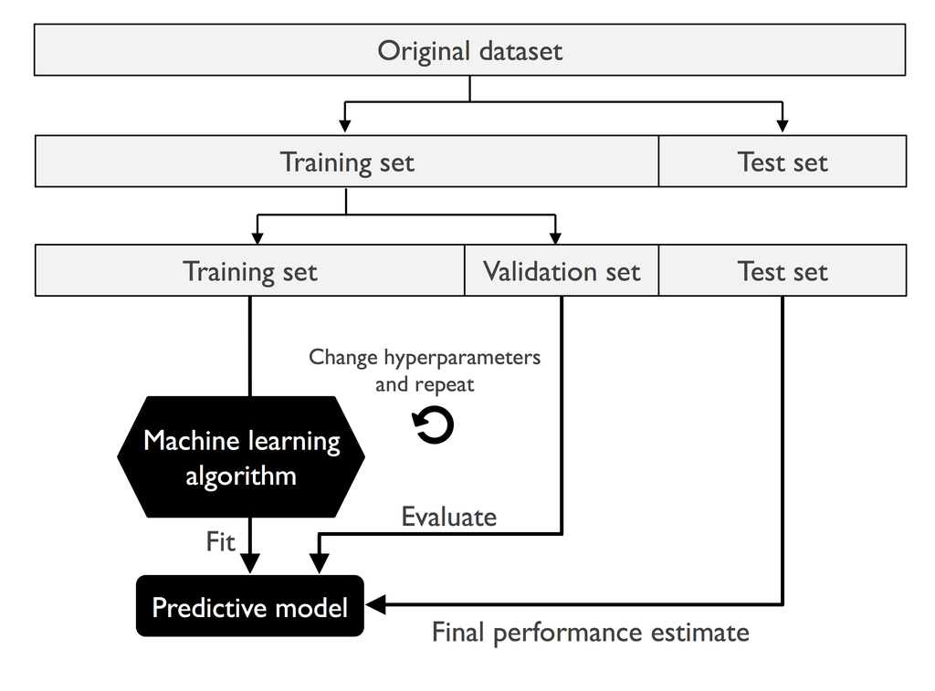

```python
Image(filename='images/06_02.png', width=500)
```

## Cross validation

There are several ways of performing cross-validation, and there are several corresponding iterators defined in scikit-learn. Each defines a `split` method, which will generate arrays of indices from the data set, each array indicating the instances to go into the training or testing set.

### `KFold`

`KFold` is arguably the simplest. It partitions the data into $k$ folds. It does not attempt to keep the proportions of classes.

```python
from sklearn.model_selection import KFold

k_fold = KFold(n_splits=10)
for train_indices, test_indices in k_fold.split(y):
    mCount =  np.sum(y[test_indices] == 0)
    bCount =  np.sum(y[test_indices] == 1)
    print("Test indices {}-{}; Test M Count: {}; Test B Count: {}; Test M/B: {}".format(test_indices[0],test_indices[-1], mCount, bCount, mCount/bCount))
```

```
Test indices 0-56; Test M Count: 57; Test B Count: 0; Test M/B: inf
Test indices 57-113; Test M Count: 57; Test B Count: 0; Test M/B: inf
Test indices 114-170; Test M Count: 57; Test B Count: 0; Test M/B: inf
Test indices 171-227; Test M Count: 41; Test B Count: 16; Test M/B: 2.5625
Test indices 228-284; Test M Count: 0; Test B Count: 57; Test M/B: 0.0
Test indices 285-341; Test M Count: 0; Test B Count: 57; Test M/B: 0.0
Test indices 342-398; Test M Count: 0; Test B Count: 57; Test M/B: 0.0
Test indices 399-455; Test M Count: 0; Test B Count: 57; Test M/B: 0.0
Test indices 456-512; Test M Count: 0; Test B Count: 57; Test M/B: 0.0
Test indices 513-568; Test M Count: 0; Test B Count: 56; Test M/B: 0.0
```

### `StratifiedKFold`

`StratifiedKFold` ensures that the proportion of classes are preserved in each training/testing set.

```python
from sklearn.model_selection import StratifiedKFold

k_fold = StratifiedKFold(n_splits=10)
for train_indices, test_indices in k_fold.split(X,y):
    mCount =  np.sum(y[test_indices] == 0)
    bCount =  np.sum(y[test_indices] == 1)
    print("Test indices {}-{}; Test M Count: {}; Test B Count: {}; Test M/B: {}".format(test_indices[0],test_indices[-1], mCount, bCount, mCount/bCount))
```

```
Test indices 0-246; Test M Count: 22; Test B Count: 35; Test M/B: 0.6285714285714286
Test indices 22-281; Test M Count: 22; Test B Count: 35; Test M/B: 0.6285714285714286
Test indices 44-317; Test M Count: 21; Test B Count: 36; Test M/B: 0.5833333333333334
Test indices 65-353; Test M Count: 21; Test B Count: 36; Test M/B: 0.5833333333333334
Test indices 86-389; Test M Count: 21; Test B Count: 36; Test M/B: 0.5833333333333334
Test indices 107-425; Test M Count: 21; Test B Count: 36; Test M/B: 0.5833333333333334
Test indices 128-461; Test M Count: 21; Test B Count: 36; Test M/B: 0.5833333333333334
Test indices 149-497; Test M Count: 21; Test B Count: 36; Test M/B: 0.5833333333333334
Test indices 170-533; Test M Count: 21; Test B Count: 36; Test M/B: 0.5833333333333334
Test indices 191-568; Test M Count: 21; Test B Count: 35; Test M/B: 0.6
```

Some recommdend using cross-validation on a training set (for model development), reserving a test set for final evaluation.

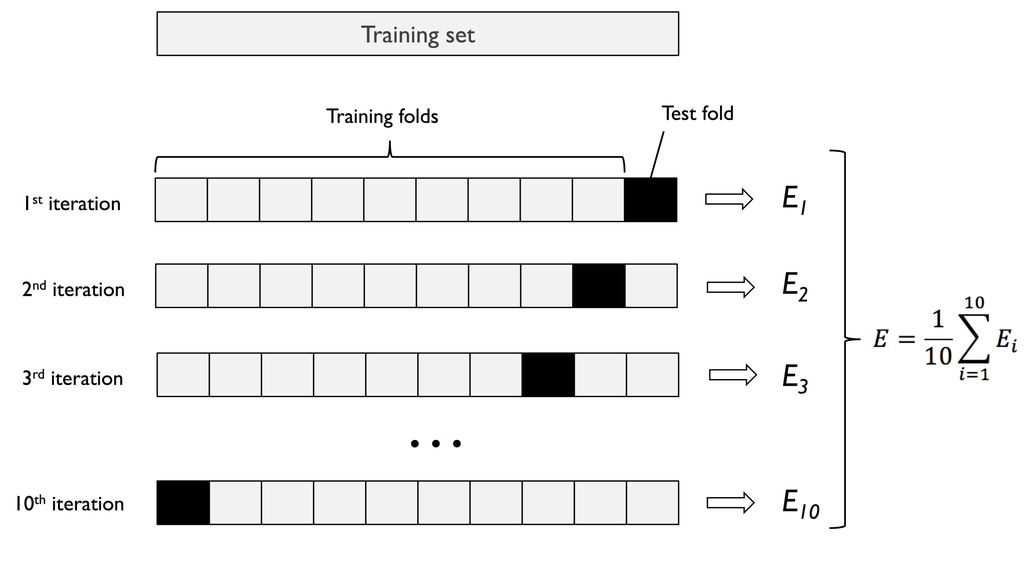

```python
Image(filename='images/06_03.png', width=500)
```

```python
from sklearn import tree
import sklearn.metrics as metrics
clf = tree.DecisionTreeClassifier()
k_fold = StratifiedKFold(n_splits=10)

scores = []
X_train, X_test, y_train, y_test =  train_test_split(X, y, test_size=0.20, stratify=y)

for train_indices, test_indices in k_fold.split(X_train,y_train):
    clf.fit(X_train[train_indices], y_train[train_indices])
    predicted = clf.predict(X_train[test_indices])
    scores.append(metrics.accuracy_score(y_train[test_indices], predicted))

for i in scores:
    print("accuracy:", i)

print("mean:",np.mean(scores))
print("std:",np.std(scores,ddof=1))



clf.fit(X_train, y_train)
predicted = clf.predict(X_test)

print("Model fitted on the entire training set and evaluated on the test set....")
print("accuracy:", metrics.accuracy_score(y_test, predicted))
```

```
accuracy: 0.8913043478260869
accuracy: 1.0
accuracy: 0.9565217391304348
accuracy: 0.8913043478260869
accuracy: 0.9130434782608695
accuracy: 0.8888888888888888
accuracy: 0.9777777777777777
accuracy: 0.8666666666666667
accuracy: 0.9777777777777777
accuracy: 0.8444444444444444
mean: 0.9207729468599034
std: 0.05335485808028493
Model fitted on the entire training set and evaluated on the test set....
accuracy: 0.9298245614035088
```

### `ShuffleSplit`

`ShuffleSplit` will generate indepedent pairs of randomly shuffled training and testing sets.

```python
from sklearn.model_selection import ShuffleSplit

clf = tree.DecisionTreeClassifier()
cv = ShuffleSplit(n_splits=10, test_size=0.20)

X_train, X_test, y_train, y_test =  train_test_split(X, y, test_size=0.20, stratify=y)

scores = []
for train_indices, test_indices in cv.split(X_train,y_train):
    clf.fit(X_train[train_indices], y_train[train_indices])
    predicted = clf.predict(X_train[test_indices])
    mCount =  np.sum(y_train[test_indices] == 0)
    bCount =  np.sum(y_train[test_indices] == 1)
    scores.append(metrics.accuracy_score(y_train[test_indices], predicted))
    print("accuracy {}; Test M Count: {}; Test B Count: {}; Test M/B: {}".format(scores[-1], mCount, bCount, mCount/bCount))

print("mean:",np.mean(scores))
print("std:",np.std(scores,ddof=1))



clf.fit(X_train, y_train)
predicted = clf.predict(X_test)

print("Model fitted on the entire training set and evaluated on the test set....")
print("accuracy:", metrics.accuracy_score(y_test, predicted))
```

```
accuracy 0.9230769230769231; Test M Count: 29; Test B Count: 62; Test M/B: 0.46774193548387094
accuracy 0.9230769230769231; Test M Count: 37; Test B Count: 54; Test M/B: 0.6851851851851852
accuracy 0.8901098901098901; Test M Count: 33; Test B Count: 58; Test M/B: 0.5689655172413793
accuracy 0.9340659340659341; Test M Count: 39; Test B Count: 52; Test M/B: 0.75
accuracy 0.9340659340659341; Test M Count: 38; Test B Count: 53; Test M/B: 0.7169811320754716
accuracy 0.9340659340659341; Test M Count: 32; Test B Count: 59; Test M/B: 0.5423728813559322
accuracy 0.9010989010989011; Test M Count: 37; Test B Count: 54; Test M/B: 0.6851851851851852
accuracy 0.9230769230769231; Test M Count: 40; Test B Count: 51; Test M/B: 0.7843137254901961
accuracy 0.945054945054945; Test M Count: 34; Test B Count: 57; Test M/B: 0.5964912280701754
accuracy 0.9120879120879121; Test M Count: 34; Test B Count: 57; Test M/B: 0.5964912280701754
mean: 0.921978021978022
std: 0.016745977217087864
Model fitted on the entire training set and evaluated on the test set....
accuracy: 0.956140350877193
```

### `StratifiedShuffleSplit`

`StratifiedShuffleSplit` will generate indepedent pairs of shuffled training and testing sets. Here, however, it will ensure the training and test sets are stratified.

```python
from sklearn.model_selection import StratifiedShuffleSplit

clf = tree.DecisionTreeClassifier()
cv = StratifiedShuffleSplit(n_splits=10, test_size=0.20)

X_train, X_test, y_train, y_test =  train_test_split(X, y, test_size=0.20, stratify=y)

scores = []
for train_indices, test_indices in cv.split(X_train,y_train):
    clf.fit(X_train[train_indices], y_train[train_indices])
    predicted = clf.predict(X_train[test_indices])
    mCount =  np.sum(y_train[test_indices] == 0)
    bCount =  np.sum(y_train[test_indices] == 1)
    scores.append(metrics.accuracy_score(y_train[test_indices], predicted))
    print("accuracy {}; Test M Count: {}; Test B Count: {}; Test M/B: {}".format(scores[-1], mCount, bCount, mCount/bCount))

print("mean:",np.mean(scores))
print("std:",np.std(scores,ddof=1))

clf.fit(X_train, y_train)
predicted = clf.predict(X_test)

print("Model fitted on the entire training set and evaluated on the test set....")
print("accuracy:", metrics.accuracy_score(y_test, predicted))
```

```
accuracy 0.967032967032967; Test M Count: 34; Test B Count: 57; Test M/B: 0.5964912280701754
accuracy 0.9010989010989011; Test M Count: 34; Test B Count: 57; Test M/B: 0.5964912280701754
accuracy 0.9120879120879121; Test M Count: 34; Test B Count: 57; Test M/B: 0.5964912280701754
accuracy 0.9120879120879121; Test M Count: 34; Test B Count: 57; Test M/B: 0.5964912280701754
accuracy 0.9340659340659341; Test M Count: 34; Test B Count: 57; Test M/B: 0.5964912280701754
accuracy 0.9230769230769231; Test M Count: 34; Test B Count: 57; Test M/B: 0.5964912280701754
accuracy 0.9010989010989011; Test M Count: 34; Test B Count: 57; Test M/B: 0.5964912280701754
accuracy 0.9560439560439561; Test M Count: 34; Test B Count: 57; Test M/B: 0.5964912280701754
accuracy 0.9120879120879121; Test M Count: 34; Test B Count: 57; Test M/B: 0.5964912280701754
accuracy 0.9560439560439561; Test M Count: 34; Test B Count: 57; Test M/B: 0.5964912280701754
mean: 0.9274725274725275
std: 0.02440781135378416
Model fitted on the entire training set and evaluated on the test set....
accuracy: 0.9122807017543859
```

### Repeated K Folds

Here, $n$ iterations of $k$ folds are generated, with different splits in each iteration.

```python
from sklearn.model_selection import RepeatedStratifiedKFold
X = np.array([1,2,3,4,5,6,7,8,9,10])
y = np.array([0, 1, 1,0,0,1,0,1,1,0])
cv = RepeatedStratifiedKFold(n_splits=5, n_repeats=2)
for train_index, test_index in cv.split(X, y):
    print(train_index, test_index)
```

```
[0 1 2 3 5 6 7 9] [4 8]
[0 1 2 3 4 7 8 9] [5 6]
[0 1 3 4 5 6 7 8] [2 9]
[2 3 4 5 6 7 8 9] [0 1]
[0 1 2 4 5 6 8 9] [3 7]
[0 2 4 5 6 7 8 9] [1 3]
[0 1 2 3 4 5 7 9] [6 8]
[0 1 2 3 6 7 8 9] [4 5]
[0 1 2 3 4 5 6 8] [7 9]
[1 3 4 5 6 7 8 9] [0 2]
```

### `cross_val_score`

`cross_val_score` provides a more convenient way of evaluating scores for each fold. The underlying `score` method is used, but this can be overridden.

```python
from sklearn.model_selection import cross_val_score

k_fold = StratifiedKFold(n_splits=10)

scores = cross_val_score(clf,X=X_train,y=y_train,cv=k_fold)

for i in scores:
    print("accuracy:", i)

print("mean:",np.mean(scores))
print("std:",np.std(scores,ddof=1))
```

```
accuracy: 0.8913043478260869
accuracy: 0.9347826086956522
accuracy: 0.9782608695652174
accuracy: 0.9347826086956522
accuracy: 0.9782608695652174
accuracy: 0.8444444444444444
accuracy: 0.9555555555555556
accuracy: 0.9333333333333333
accuracy: 0.8666666666666667
accuracy: 0.9111111111111111
mean: 0.9228502415458937
std: 0.04477348501531407
```

### `cross_val_predict`

Note that if k-fold cross validation is used, each instance in the training set will be used at some point as a test instance. `cross_val_predict` returns the predicted value of each instance.

```python
from sklearn.model_selection import cross_val_predict
predicted = cross_val_predict(clf,X=X_train,y=y_train,cv=k_fold)
print("accuracy:", metrics.accuracy_score(y_train, predicted))
```

```
accuracy: 0.9296703296703297
```